# Plot phylogeny results

In this notebook, we will plot the phylogenies obtained with parsimony and Bayesian inference for Anchylorhynchus. We will also use the Bayesian tree with branch lengths to infer the geographical history and host change history of Anchylorhynchus.

Let’s first load packages.

```r
library(phytools)
library(tidyverse)
library(cowplot)
library(corHMM)
rm(list=ls())
```

# Plot trees

To facilitate tree plotting, we opened the TNT and MrBayes trees (summarized with sumtrees in dendropy) in figtree, rerooted and ladderized them, and saved as annotated nexus before opening here.

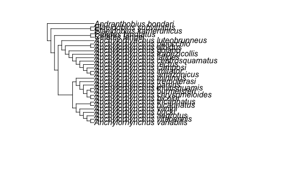

```r
tnt = ape::read.nexus('tnt_symboot_rooted.tre')
plot(tnt)
```

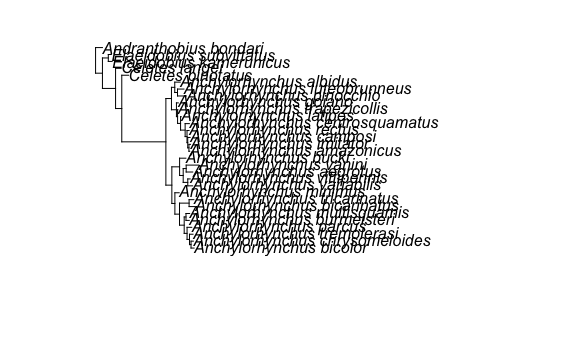

```r
mb = ape::read.nexus('mrbayes_alphasampled_consensus_rooted.tre')
plot(mb)
```

Now let’s create a cophylo object to rotate branches and maximize matches. We will then extract rotated trees to plot them with ggtree

```r
cop = cophylo(mb,tnt)
```

```
Rotating nodes to optimize matching...
Done.
```

```r
mb = cop$trees[[1]]
tnt = cop$trees[[2]]
```

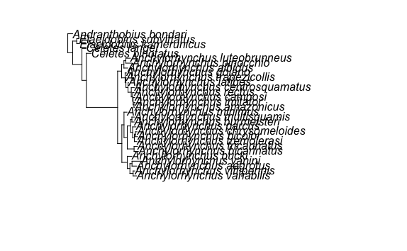

```r
plot(mb)
```

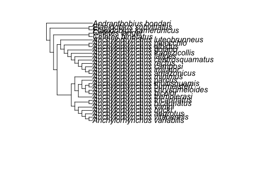

```r
plot(tnt)
```

Now let’s load ggtree to make pretty plots.

```r
library(treeio)
library(ggtree)
```

```r
tnt_io = treeio::read.beast('tnt_symboot_rooted.tre')
mb_io = treeio::read.beast('mrbayes_alphasampled_consensus_rooted.tre')
```

Now, we define a function to find the corresponding node in the new tree.

```r
find_new_node = function(nd,old_tr, new_tr){
  nd = as.integer(nd)
  if (nd > Ntip(old_tr)){
    tips = extract.clade(old_tr, nd)$tip.label
    new_node = getMRCA(new_tr, tips)
  } else {
    new_node = match(old_tr$tip.label[as.integer(nd)],new_tr$tip.label)
  }

  return(new_node)
}
```

With the new function, we can update the tree and associated data.

```r
tnt_io@data = tnt_io@data %>%
  rowwise %>%
  mutate(node = find_new_node(as.integer(node),tnt_io@phylo, tnt))

tnt_io@phylo = tnt

mb_io@data = mb_io@data %>%
  rowwise %>%
  mutate(node = find_new_node(as.integer(node),mb_io@phylo, mb))

mb_io@phylo = mb
```

Let’s now shorten tip labels:

```r
mb_io@phylo$tip.label = stringr::str_replace(mb_io@phylo$tip.label,'^(.).+_','\\1.~') %>%
  stringr::str_c('italic(',.,')')

tnt_io@phylo$tip.label = stringr::str_replace(tnt_io@phylo$tip.label,'^(.).+_','\\1.~') %>%
  stringr::str_c('italic(',.,')')
```

For some reason, posterior probability in the Bayesian tree is a factor, let’s change it to continuous. Let’s also remove posterior probabilities from tips.

```r
mb_io@data = mb_io@data %>%
  mutate(prob_percent = 100*as.numeric(posterior),
         node = as.numeric(node),
         prob_pct2 = ifelse(node <= Ntip(mb_io@phylo),
                            NA,
                            prob_percent))
```

TNT saved both bootstrap frequencies and “frequency differences”(GC), let’s keep only frequencies and change to numeric.

```r
tnt_io@data = tnt_io@data %>%
  mutate(bootstrap = str_split(bootstrap,'/',simplify = F) %>%
           purrr::map(1) %>%
           as.numeric())
```

Now let’s plot each tree separately

```r
t1 = ggtree(mb_io, aes(color=prob_pct2), size= 0.25, ladderize = F) +
  geom_tiplab(parse=T,
              align=TRUE,
              #offset=0.3,
              linetype='dashed',
              size=2.5,
              linesize = 0.25) +
  scale_color_viridis_c(na.value = 'black', limits= c(0,100),expand=c(0,0),name='Support') +
  geom_treescale(x = 1, y = 5,fontsize = 2.25,width = 0.5,linesize = 0.25) +
  xlim(c(0,5)) +
  theme_tree() +
  theme(legend.position = 'bottom',
        legend.title = element_text(size=8),
        legend.text = element_text(size=7))
```

```
Duplicated aesthetics after name standardisation: sizeIgnoring unknown parameters: parse
```

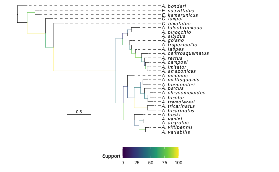

```r
t1
```

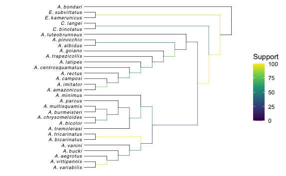

```r
t2 = ggtree(tnt_io, aes(color=bootstrap), size=0.25, ladderize = F) +
  scale_x_reverse() +
  xlim(c(19,0)) +
  geom_tiplab(parse=T,
              hjust = 1,
              offset=-0.15,
              size=2.5) +
  scale_color_viridis_c(na.value = 'black', limits= c(0,100),expand=c(0,0),name='Support') +
  theme_tree()
t2
```

Let’s now plot the two together as a figure using cowplot:

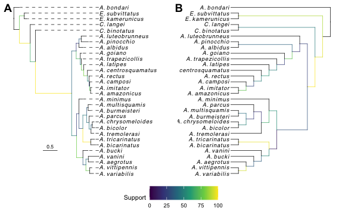

```r
lg = cowplot::get_legend(t1)
p = cowplot::plot_grid(t1 + theme(legend.position="none"),
                   t2 + theme(legend.position="none"),
                   align = 'vh',
                    labels = LETTERS[1:2],
           nrow = 1) %>%
  plot_grid(lg, ncol = 1, rel_heights = c(1, .15))
p
ggsave('trees.pdf',p,'pdf',width=168,height=120,units = 'mm',useDingbats=F)
```

# Characters

How many characters are autapomorphies? First, let’s parse the character matrix as a tidy table.

```r
chars = scan('anchylorhynchus_chars.txt',what = character(),sep = '\n') %>%
  str_split(' ',simplify = T) %>%
  as_tibble() %>%
  rowwise %>%
  mutate(chars = str_split(V2,'[\\(\\)]') %>%
           purrr::map(~ifelse(str_detect(.x,','),.x,str_split(.x,''))) %>%
           unlist %>%
           list(.)
         ) %>%
  select(species=V1, chars) %>%
  tidyr::unnest(chars) %>%
  mutate(character=rep(1:113,30)) %>%
  mutate(chars = na_if(chars,'?'),
         chars = na_if(chars,'-'),
         chars = str_split(chars,',')) %>%
  rename(state = chars,
         char = character)
```

```
Read 30 items
The `x` argument of `as_tibble.matrix()` must have column names if `.name_repair` is omitted as of tibble 2.0.0.
Using compatibility `.name_repair`.
```

```r
chars
```

| species | state | char |
| --- | --- | --- |
| Anchylorhynchus_aegrotus |  | 1 |
| Anchylorhynchus_aegrotus |  | 2 |
| Anchylorhynchus_aegrotus |  | 3 |
| Anchylorhynchus_aegrotus |  | 4 |
| Anchylorhynchus_aegrotus |  | 5 |
| Anchylorhynchus_aegrotus |  | 6 |
| Anchylorhynchus_aegrotus |  | 7 |
| Anchylorhynchus_aegrotus |  | 8 |
| Anchylorhynchus_aegrotus |  | 9 |
| Anchylorhynchus_aegrotus |  | 10 |

[output cut: 990 more lines]

Now, its easy to do statistics on the matrix. For example, how many characters are binary?

```r
chars %>%
  group_by(char) %>%
  summarise(all_states = na.exclude(unique(unlist(state))) %>% length()) %>%
  filter(all_states == 2) %>%
  nrow
```

```
[1] 50
```

And how many are not binary?

```r
chars %>%
  group_by(char) %>%
  summarise(all_states = na.exclude(unique(unlist(state))) %>% length()) %>%
  filter(all_states > 2) %>%
  nrow
```

```
[1] 63
```

How much missing data is there?

```r
nrow(filter(chars,is.na(state))) / nrow(chars)
```

```
[1] 0.04306785
```

How many were polymorphic?

```r
nstates = chars %>%
  unnest(state) %>%
  group_by(species,char) %>%
  summarise(Nst=n()) %>%
  group_by(Nst) %>%
  summarise(N = n())

(sum(filter(nstates,Nst>1) %>% pull(N)) )/  sum(nstates$N)
```

```
[1] 0.04041298
```

How many binary traits are autapomorhies?

```r
bin = chars %>%
  group_by(char) %>%
  summarise(all_states = na.exclude(unique(unlist(state))) %>% length()) %>%
  filter(all_states == 2) %>%
  pull(char) %>%
  unique()

chars %>%
  filter(char %in% bin) %>%
  filter(!is.na(state)) %>%
  unnest(state) %>%
  group_by(char,state) %>%
  summarise(N= n()) %>%
  filter(N==1) %>%
  nrow
```

```
[1] 10
```

To figure out which traits are autapomorphies, we will use Mesquite, since TNT output is very hard to parse.

# Palm association

Let’s read the table with palm associations.

```r
palms = readr::read_csv('palm_associations.csv')
palms
```

| species | Syagrus | Butia | Oenocarpus | Euterpe |
| --- | --- | --- | --- | --- |
| Anchylorhynchus_aegrotus | 1 | 0 | 0 | 0 |
| Anchylorhynchus_albidus | 1 | 0 | 0 | 0 |
| Anchylorhynchus_amazonicus | 1 | 0 | 0 | 0 |
| Anchylorhynchus_imitator | 1 | 0 | 0 | 0 |
| Anchylorhynchus_bicarinatus | 0 | 0 | 1 | 0 |
| Anchylorhynchus_bicolor | 0 | 1 | 0 | 0 |
| Anchylorhynchus_bucki | 1 | 0 | 0 | 0 |
| Anchylorhynchus_burmeisteri | 0 | 1 | 0 | 0 |
| Anchylorhynchus_multisquamis | 1 | 0 | 0 | 0 |
| Anchylorhynchus_camposi | 1 | 0 | 0 | 0 |

[output cut: 15 more lines]

Now let’s use the function `rayDisc` in package `corHMM` to do ancestral state reconstruction under different models and choose model by the AIC. We use this function because it can handle polymorphisms and missing data. We will also remove the outgroup since it is not particularly well sampled.

Let’s start by formatting the tree and character as required by rayDisc.

```r
anc_only = ape::drop.tip(mb,c("Celetes_binotatus", "Celetes_langei", "Andranthobius_bondari", "Elaeidobius_kamerunicus", "Elaeidobius_subvittatus"))

hosts = palms %>%
  gather(-species, key=palm,value=association) %>%
  mutate(palm = as.factor(palm))

palm_trans = levels(hosts$palm)

hosts = hosts %>%
  mutate(palm = as.integer(palm)) %>%
  filter(association==1) %>%
  group_by(species) %>%
  summarise(palm=ifelse(n() == 4,'?', str_c(unique(palm),collapse='&')))

hosts
```

| species | palm |
| --- | --- |
| Anchylorhynchus_aegrotus | 4 |
| Anchylorhynchus_albidus | 4 |
| Anchylorhynchus_amazonicus | 4 |
| Anchylorhynchus_bicarinatus | 3 |
| Anchylorhynchus_bicolor | 1 |
| Anchylorhynchus_bucki | 4 |
| Anchylorhynchus_burmeisteri | 1 |
| Anchylorhynchus_camposi | 4 |
| Anchylorhynchus_centrosquamatus | 4 |
| Anchylorhynchus_chrysomeloides | 1 |

[output cut: 15 more lines]

```r
NA
```

Now let’s run the reconstruction using 3 different models (equal rates, symmetric and asymmetric).

```r
sim_foo = function(md){

  a = rayDISC(anc_only,
              data = as.data.frame(hosts),
              model = md,
              node.states='marginal',
            root.p = 'maddfitz')

  return(a)
}

models = c('ARD','ER','SYM')
names(models) = models

results = models %>%
  purrr::map(~sim_foo(.x))
```

```
State distribution in data:
States: ?   1   2   3   4   4&1
Counts: 1   4   1   2   16  1
Initializing...
Finished. Beginning thorough search...
Finished. Inferring ancestral states using marginal reconstruction.
State distribution in data:
States: ?   1   2   3   4   4&1
Counts: 1   4   1   2   16  1
Initializing...
Finished. Beginning thorough search...
Finished. Inferring ancestral states using marginal reconstruction.
State distribution in data:
States: ?   1   2   3   4   4&1
Counts: 1   4   1   2   16  1
Initializing...
Finished. Beginning thorough search...
Finished. Inferring ancestral states using marginal reconstruction.
```

Let’s compare the 3 models now.

```r
purrr::map_df(results,
              ~tibble(loglik = .x$loglik,
                      AIC = .x$AIC,
                      AICc = .x$AICc),
              .id = 'model') %>%
  arrange(AIC) %>%
  mutate(AICw = exp(-0.5*(AICc-min(AICc))) / sum(exp(-0.5*(AICc-min(AICc)))) )
```

| model | loglik | AIC | AICc | AICw |
| --- | --- | --- | --- | --- |
| ER | -14.93272 | 31.86545 | 32.03936 | 9.978140e-01 |
| SYM | -13.80984 | 39.61969 | 44.28635 | 2.185994e-03 |
| ARD | -11.15811 | 46.31621 | 72.31621 | 1.790780e-09 |

An equal rates model seems to be best, let’s plot the marginal reconstructions onto the tree now.

Let’s now plot pies using ggtree. First, let’s get the pie data.

```r
node_pies = results$ER$states %>%
  as.data.frame() %>%
  rownames_to_column('node') %>%
  mutate(node = as.numeric(node) + Ntip(anc_only))

names(node_pies) = c('node',palm_trans)

tip_pies = palms %>%
  mutate(node = match(species, anc_only$tip.label)) %>%
#  mutate( species = species %>%
#            str_replace('Anchylorhynchus_','A.~') %>%
#            str_c('italic(',.,')') ) %>%
  mutate(None = ifelse(str_detect(species,'parcus'),1,0))

tip_pies[tip_pies$species == 'Anchylorhynchus_parcus',
         c('Syagrus','Butia','Oenocarpus','Euterpe')] = 0


node_pies = bind_rows(mutate(node_pies,None=0),
                      select(tip_pies,-species)) %>%
  rename(Unknown=None)

node_pies
```

| node | Butia | Euterpe | Oenocarpus | Syagrus | Unknown |
| --- | --- | --- | --- | --- | --- |
| 26 | 6.521196e-06 | 6.602005e-05 | 2.295919e-06 | 0.9999251628 | 0 |
| 27 | 1.487677e-02 | 4.000511e-02 | 8.677768e-03 | 0.9364403577 | 0 |
| 28 | 5.700013e-04 | 1.142301e-03 | 4.167963e-04 | 0.9978709017 | 0 |
| 29 | 9.361044e-05 | 8.865938e-05 | 5.949556e-05 | 0.9997582346 | 0 |
| 30 | 8.267345e-04 | 6.699580e-05 | 6.589463e-05 | 0.9990403751 | 0 |
| 31 | 1.830343e-04 | 1.820489e-04 | 1.762440e-04 | 0.9994586728 | 0 |
| 32 | 1.098738e-01 | 3.119540e-01 | 5.902701e-02 | 0.5191451957 | 0 |
| 33 | 3.708928e-01 | 1.355833e-01 | 1.878515e-01 | 0.3056724754 | 0 |
| 34 | 9.996664e-03 | 4.739509e-03 | 9.767243e-01 | 0.0085395481 | 0 |
| 35 | 8.126642e-01 | 8.654684e-03 | 1.154306e-02 | 0.1671380778 | 0 |

[output cut: 39 more lines]

And now plot.

```r
cls = c(RColorBrewer::brewer.pal(n=4,name='Set1'),'#333333')
names(cls) = c(names(node_pies)[2:6])

pies = nodepie(node_pies, cols = 2:6)
pies = lapply(pies, function(g) g + scale_fill_manual(values = cls))

base_tr = anc_only
base_tr$tip.label = stringr::str_replace(base_tr$tip.label,'^(.).+_','\\1.~') %>%
  stringr::str_c('italic(',.,')')

p = ggtree(as.treedata(base_tr),  size=0.25, ladderize = F) +
    scale_fill_manual(values = cls, guide = guide_legend()) +
  geom_tiplab(parse=T,
              offset=0.02,
              size=2.5) +
  geom_inset(pies,
             width = .1,
             height = .1) +
  xlim(0,1.1) +
  theme_tree(legend.position = "right")
```

```
Unknown or uninitialised column: `node`.Loading required package: ggimage
```

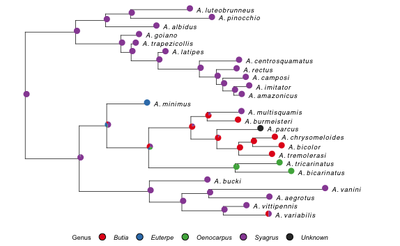

```r
lg = data.frame(Genus = c(names(cls)[1:4],'Unknown'),x = 1:5) %>%
  ggplot(aes(fill = Genus,x=x,y=x)) +
  geom_point(shape=21) +
  scale_fill_manual(values = cls, guide=guide_legend(name = 'Host genus',
                                                     override.aes = list(size=3))) +
  theme(legend.position = 'bottom',
        legend.key = element_blank(),
        legend.title = element_text(size=7),
        legend.text = element_text(size=7,face='italic'))


lg = cowplot::get_legend(lg)

cowplot::plot_grid(p,
                   lg,
           ncol = 1, rel_heights = c(1, .08))

ggsave(filename = 'hosts.pdf',
       device = 'pdf',
       width = 168,
       height = 120,
       units = 'mm',
       useDingbats = F)
```